# Проект "Анализ гипотез для интернет-магазина"

**Описание проекта**

Вы — аналитик крупного интернет-магазина. Вместе с отделом маркетинга вы подготовили список гипотез для увеличения выручки.

**Цель проекта**: найти возможности для увеличения выручки крупного интернет-магазина.

**Задачи проекта**:

- приоритизировать гипотезы;
- проверить корректность проведения и результатов A/B-теста;
- провести статистический анализ результатов A/B-теста.

**Используемые инструменты**:

- python
- pandas
- numpy
- matplotlib
- scipy

**План работы**:

1. Загрузить и данные и выполнить их предобработку.
2. Приоритизировать имеющиеся гипотезы.
   1. Примените фреймворк ICE для приоритизации гипотез. Отсортируйте их по убыванию приоритета.
   2. Примените фреймворк RICE для приоритизации гипотез. Отсортируйте их по убыванию приоритета.
   3. Укажите, как изменилась приоритизация гипотез при применении RICE вместо ICE. Объясните, почему так произошло.
3. Провести исследовательский анализ данных:
   1. Постройте график кумулятивной выручки по группам. Сделайте выводы и предположения.
   2. Постройте график кумулятивного среднего чека по группам. Сделайте выводы и предположения.
   3. Постройте график относительного изменения кумулятивного среднего чека группы B к группе A. Сделайте выводы и предположения.
   4. Постройте график кумулятивного среднего количества заказов на посетителя по группам. Сделайте выводы и предположения.
   5. Постройте график относительного изменения кумулятивного среднего количества заказов на посетителя группы B к группе A. Сделайте выводы и предположения.
   6. Постройте точечный график количества заказов по пользователям. Сделайте выводы и предположения.
   7. Посчитайте 95-й и 99-й перцентили количества заказов на пользователя. Выберите границу для определения аномальных пользователей.
   8. Постройте точечный график стоимостей заказов. Сделайте выводы и предположения.
   9. Посчитайте 95-й и 99-й перцентили стоимости заказов. Выберите границу для определения аномальных заказов.
4. Провести статистический анализ результатов A/B-теста:
   1. Посчитайте статистическую значимость различий в среднем количестве заказов на посетителя между группами по «сырым» данным. Сделайте выводы и предположения.
   2. Посчитайте статистическую значимость различий в среднем чеке заказа между группами по «сырым» данным. Сделайте выводы и предположения.
   3. Посчитайте статистическую значимость различий в среднем количестве заказов на посетителя между группами по «очищенным» данным. Сделайте выводы и предположения.
   4. Посчитайте статистическую значимость различий в среднем чеке заказа между группами по «очищенным» данным. Сделайте выводы и предположения.
   5. Примите решение по результатам теста и объясните его.
5. Сделать общий вывод.

**Описание данных**

Файл hypothesis.csv.

**Hypothesis** — краткое описание гипотезы;

**Reach** — охват пользователей по 10-балльной шкале;

**Impact** — влияние на пользователей по 10-балльной шкале;

**Confidence** — уверенность в гипотезе по 10-балльной шкале;

**Efforts** — затраты ресурсов на проверку гипотезы по 10-балльной шкале. Чем больше значение Efforts, тем дороже проверка гипотезы.

Файл orders.csv.

**transactionId** — идентификатор заказа;

**visitorId** — идентификатор пользователя, совершившего заказ;

**date** — дата, когда был совершён заказ;

**revenue** — выручка заказа;

**group** — группа A/B-теста, в которую попал заказ.

Файл visitors.csv.

**date** — дата;

**group** — группа A/B-теста;

**visitors** — количество пользователей в указанную дату в указанной группе A/B-теста

## Загрузка и предобработка данных

### Загрузка данных

```python
#импорт необходимых библиотек
import pandas as pd

import matplotlib.pyplot as plt

import numpy as np

from scipy import stats as st

#настройка ширины отображаемых колонок
pd.set_option('max_colwidth', 120)
```

Датасет hypothesis.csv - загрузка, вывод.

```python
hypothesis = pd.read_csv('hypothesis.csv')

hypothesis.head(20)
```

|  | Hypothesis | Reach | Impact | Confidence | Efforts |
| --- | --- | --- | --- | --- | --- |
| 0 | Добавить два новых канала привлечения трафика, что позволит привлекать на 30% больше пользователей | 3 | 10 | 8 | 6 |
| 1 | Запустить собственную службу доставки, что сократит срок доставки заказов | 2 | 5 | 4 | 10 |
| 2 | Добавить блоки рекомендаций товаров на сайт интернет магазина, чтобы повысить конверсию и средний чек заказа | 8 | 3 | 7 | 3 |
| 3 | Изменить структура категорий, что увеличит конверсию, т.к. пользователи быстрее найдут нужный товар | 8 | 3 | 3 | 8 |
| 4 | Изменить цвет фона главной страницы, чтобы увеличить вовлеченность пользователей | 3 | 1 | 1 | 1 |
| 5 | Добавить страницу отзывов клиентов о магазине, что позволит увеличить количество заказов | 3 | 2 | 2 | 3 |
| 6 | Показать на главной странице баннеры с актуальными акциями и распродажами, чтобы увеличить конверсию | 5 | 3 | 8 | 3 |
| 7 | Добавить форму подписки на все основные страницы, чтобы собрать базу клиентов для email-рассылок | 10 | 7 | 8 | 5 |
| 8 | Запустить акцию, дающую скидку на товар в день рождения | 1 | 9 | 9 | 5 |

Датасет orders.csv - загрузка, первые 20 строк, основная информация.

```python
orders = pd.read_csv('orders.csv')

orders.head(20)
```

|  | transactionId | visitorId | date | revenue | group |
| --- | --- | --- | --- | --- | --- |
| 0 | 3667963787 | 3312258926 | 2019-08-15 | 1650 | B |
| 1 | 2804400009 | 3642806036 | 2019-08-15 | 730 | B |
| 2 | 2961555356 | 4069496402 | 2019-08-15 | 400 | A |
| 3 | 3797467345 | 1196621759 | 2019-08-15 | 9759 | B |
| 4 | 2282983706 | 2322279887 | 2019-08-15 | 2308 | B |
| 5 | 182168103 | 935554773 | 2019-08-15 | 2210 | B |
| 6 | 398296753 | 2900797465 | 2019-08-15 | 1860 | B |
| 7 | 2626614568 | 78758296 | 2019-08-15 | 1044 | A |
| 8 | 1576988021 | 295230930 | 2019-08-15 | 13710 | A |
| 9 | 1506739906 | 1882260405 | 2019-08-15 | 1855 | B |
| 10 | 3649131742 | 879864040 | 2019-08-15 | 4008 | A |
| 11 | 1919444843 | 927791387 | 2019-08-15 | 4499 | B |
| 12 | 2809384911 | 3213223594 | 2019-08-15 | 7370 | A |
| 13 | 3044797713 | 728063420 | 2019-08-15 | 11985 | B |
| 14 | 3859315276 | 1565034404 | 2019-08-15 | 10980 | A |
| 15 | 2550768810 | 2742574263 | 2019-08-15 | 15277 | B |
| 16 | 1820531107 | 2973109265 | 2019-08-15 | 1060 | B |
| 17 | 1108180333 | 222718357 | 2019-08-15 | 990 | B |
| 18 | 1822256754 | 4227830084 | 2019-08-15 | 16490 | A |
| 19 | 674584210 | 3207734412 | 2019-08-15 | 1190 | A |

```python
orders.info()
```

```
<class 'pandas.core.frame.DataFrame'>
RangeIndex: 1197 entries, 0 to 1196
Data columns (total 5 columns):
 #   Column         Non-Null Count  Dtype
---  ------         --------------  -----
 0   transactionId  1197 non-null   int64
 1   visitorId      1197 non-null   int64
 2   date           1197 non-null   object
 3   revenue        1197 non-null   int64
 4   group          1197 non-null   object
dtypes: int64(3), object(2)
memory usage: 46.9+ KB
```

Датасет visitors.csv - загрузка, первые 20 строк, основная информация.

```python
visitors = pd.read_csv('visitors.csv')

visitors.head(20)
```

|  | date | group | visitors |
| --- | --- | --- | --- |
| 0 | 2019-08-01 | A | 719 |
| 1 | 2019-08-02 | A | 619 |
| 2 | 2019-08-03 | A | 507 |
| 3 | 2019-08-04 | A | 717 |
| 4 | 2019-08-05 | A | 756 |
| 5 | 2019-08-06 | A | 667 |
| 6 | 2019-08-07 | A | 644 |
| 7 | 2019-08-08 | A | 610 |
| 8 | 2019-08-09 | A | 617 |
| 9 | 2019-08-10 | A | 406 |
| 10 | 2019-08-11 | A | 718 |
| 11 | 2019-08-12 | A | 595 |
| 12 | 2019-08-13 | A | 748 |
| 13 | 2019-08-14 | A | 735 |
| 14 | 2019-08-15 | A | 628 |
| 15 | 2019-08-16 | A | 361 |
| 16 | 2019-08-17 | A | 412 |
| 17 | 2019-08-18 | A | 668 |
| 18 | 2019-08-19 | A | 502 |
| 19 | 2019-08-20 | A | 575 |

```python
visitors.info()
```

```
<class 'pandas.core.frame.DataFrame'>
RangeIndex: 62 entries, 0 to 61
Data columns (total 3 columns):
 #   Column    Non-Null Count  Dtype
---  ------    --------------  -----
 0   date      62 non-null     object
 1   group     62 non-null     object
 2   visitors  62 non-null     int64
dtypes: int64(1), object(2)
memory usage: 1.6+ KB
```

Данные отображаются корректно.

Названия столбцов нуждаются в приведении к правильному стилю.

Необходимо привести столбцы **date** в датафреймах **orders** и **visitors** к типу pandas datetime.

Пропусков в датасетах нет.

### Предобработка данных

#### Переименование столбцов

```python
#перевод названий столбцов датафрйма "hypothesis" в нижний регистр
hypothesis.columns = hypothesis.columns.str.lower()

#переименование столбцов датафрейма "orders"
orders = orders.rename(columns={
    'transactionId':'transaction_id',
    'visitorId':'visitor_id'
})
```

#### Приведение столбцов **date** в датафреймах **orders** и **visitors** к типу pandas datetime

```python
orders['date'] = pd.to_datetime(orders['date'])

visitors['date'] = pd.to_datetime(visitors['date'])
```

#### Обработка дубликатов

```python
#вывод явных дубликатов датафреймов
display(hypothesis.duplicated().sum())
display(orders.duplicated().sum())
display(visitors.duplicated().sum())
```

```
0
```

```
0
```

```
0
```

Явных дубликатов нет.

#### Изучим значения в столбцах датафреймов **orders** и **visitors** на предмет явных аномалий и ошибок

```python
#вывод количества значений столбцов
for col in orders.columns:
    display(f'Количества значений столбца "{col}" датафрейма orders:',
            orders[col].value_counts())
```

```
'Количества значений столбца "transaction_id" датафрейма orders:'
```

```
1658608862    1
2211880073    1
3913205113    1
437656952     1
3592105335    1
             ..
2872509092    1
2013919907    1
3154167297    1
2960804513    1
4281129020    1
Name: transaction_id, Length: 1197, dtype: int64
```

```
'Количества значений столбца "visitor_id" датафрейма orders:'
```

```
4256040402    11
2458001652    11
2378935119     9
2038680547     8
199603092      5
              ..
2406916810     1
1255412427     1
3866069709     1
54447517       1
3013339133     1
Name: visitor_id, Length: 1031, dtype: int64
```

```
'Количества значений столбца "date" датафрейма orders:'
```

```
2019-08-05    48
2019-08-12    47
2019-08-14    47
2019-08-15    46
2019-08-06    46
2019-08-01    45
2019-08-28    45
2019-08-02    44
2019-08-27    44
2019-08-08    43
2019-08-19    43
2019-08-29    42
2019-08-07    42
2019-08-26    41
2019-08-22    41
2019-08-09    41
2019-08-03    40
2019-08-23    40
2019-08-10    39
2019-08-16    38
2019-08-21    37
2019-08-30    35
2019-08-13    35
2019-08-04    33
2019-08-20    32
2019-08-31    32
2019-08-24    31
2019-08-18    26
2019-08-11    26
2019-08-17    24
2019-08-25    24
Name: date, dtype: int64
```

```
'Количества значений столбца "revenue" датафрейма orders:'
```

```
990       17
890       13
390       13
1190      10
400       10
          ..
6440       1
45780      1
725        1
9800       1
202740     1
Name: revenue, Length: 713, dtype: int64
```

```
'Количества значений столбца "group" датафрейма orders:'
```

```
B    640
A    557
Name: group, dtype: int64
```

Явных ошибок нет. Столбец **revenue** и количество заказов на посетителя необходимо будет проверить на наличие аномальных значений и выбросов на этапе анализа результатов A/B-теста.

```python
#вывод количества значений столбцов
for col in visitors.columns:
    display(f'Количества значений столбца "{col}" датафрейма visitors:',
            visitors[col].value_counts())
```

```
'Количества значений столбца "date" датафрейма visitors:'
```

```
2019-08-27    2
2019-08-24    2
2019-08-08    2
2019-08-14    2
2019-08-20    2
2019-08-26    2
2019-08-01    2
2019-08-07    2
2019-08-13    2
2019-08-19    2
2019-08-25    2
2019-08-31    2
2019-08-06    2
2019-08-12    2
2019-08-18    2
2019-08-30    2
2019-08-21    2
2019-08-05    2
2019-08-11    2
2019-08-17    2
2019-08-23    2
2019-08-29    2
2019-08-04    2
2019-08-10    2
2019-08-16    2
2019-08-22    2
2019-08-28    2
2019-08-03    2
2019-08-09    2
2019-08-15    2
2019-08-02    2
Name: date, dtype: int64
```

```
'Количества значений столбца "group" датафрейма visitors:'
```

```
A    31
B    31
Name: group, dtype: int64
```

```
'Количества значений столбца "visitors" датафрейма visitors:'
```

```
610    2
718    2
654    2
490    2
609    1
717    1
719    1
720    1
721    1
594    1
722    1
468    1
595    1
756    1
735    1
```

[output cut: 44 more lines]

Явных ошибок нет.

### Проверка корректности сбора данных для A/B теста

#### Подсчитаем количество уникальных посетителей в каждой группе и корректность системы разбиения посетителей на группы

```python
display(
    'Количество уникальных покупателей в группе А: ',
    orders[orders['group'] == 'A']['visitor_id'].nunique(),
    'Количество уникальных покупателей в группе B:',
    orders[orders['group'] == 'B']['visitor_id'].nunique(),
    'Количество уникальных покупателей, попавших в обе группы:',
    (orders.groupby('visitor_id', as_index=False)['group']
        .agg('nunique')
     .query('group > 1')['visitor_id']
     .count()),

)
```

```
'Количество уникальных покупателей в группе А: '
```

```
503
```

```
'Количество уникальных покупателей в группе B:'
```

```
586
```

```
'Количество уникальных покупателей, попавших в обе группы:'
```

```
58
```

В датафрейме **orders** есть строки с заказами, оформленными посетителями, попавшими в обе группы. Проверим, сколько таких строк в датафрейме.

```python
#список посетителей, попавших в обе группы
visitors_both_groups = (
    orders
    .groupby('visitor_id', as_index=False)['group']
    .agg('nunique').query('group > 1')['visitor_id']
)

#строки датафрейма orders с посетителями, попавшмих в обе группы
orders.query('visitor_id in @visitors_both_groups')
```

|  | transaction_id | visitor_id | date | revenue | group |
| --- | --- | --- | --- | --- | --- |
| 2 | 2961555356 | 4069496402 | 2019-08-15 | 400 | A |
| 20 | 2904772834 | 963407295 | 2019-08-15 | 300 | B |
| 23 | 4252514150 | 351125977 | 2019-08-15 | 15185 | B |
| 24 | 1162046357 | 3234906277 | 2019-08-15 | 7555 | B |
| 26 | 2223239646 | 199603092 | 2019-08-15 | 3488 | A |
| ... | ... | ... | ... | ... | ... |
| 1182 | 2682156369 | 1668030113 | 2019-08-14 | 1290 | B |
| 1183 | 1458356232 | 963407295 | 2019-08-14 | 4940 | A |
| 1184 | 1329499668 | 2949041841 | 2019-08-14 | 10380 | B |
| 1189 | 4082620617 | 393266494 | 2019-08-14 | 31550 | B |
| 1195 | 1947021204 | 1614305549 | 2019-08-14 | 100 | A |

181 rows × 5 columns

58 покупателей попали в обе группы, что говорит о проблеме в системе разбиения трафика при проведении A/B-теста. Процент таких посетителей довольно большой (5,3% от общего количества). Процент строк в соответствующем датафрейме ещё больше - 15,12%. Такое большое количество совершенно точно создаёт существенные искажения в данных, в результаты теста: поскольку они работали с обеими версиями интернет-магазина, невозможно с уверенностью утверждать, какая версия повлияла на их поведение, а значит, результаты теста, учитывающие данные об этих пользователях, нельзя считать корректными. Тем не менее, удалить таких пользователей нельзя, потому что это приведёт в слишком большой (более 10%) потере данных. Кроме того, пришлось бы также удалить данные опосещениях этих пользователей из датафрейма **visits**, чтобы датафреймы остались релевантны друг другу. В таких условиях нужно провести анализ результатов теста с имеющимися данными, но обратить на эту ситуацию внимание заказчика.

### Вывод по разделу предобработки данных

Данные загружены, названия столбцов приведены к правильному стилю. Столбцы датафреймов, содержащие даты, приведены к типу данных pandas datetime.

Дубликатов и явных ошибок нет. Столбец **revenue** и количество заказов на посетителя необходимо будет проверить на наличие аномальных значений и выбросов на этапе анализа результатов A/B-теста.

58 покупателей (5,3% от общего количества) попали в обе группы, что говорит о проблеме в системе разбиения трафика при проведении A/B-теста; данные о заказах таких пользователей содержатся в 181 строке (15,1%) датафрейма **orders**, что приведёт к искажению данных. Поэтому к результатам теста и их анализу нужно отнестись с осторожностью.

## Приоритизация гипотез

### Применение фреймворка ICE

```python
#датафрейм гипотез с оценками по ICE
hypothesis.assign(
    ice =round(hypothesis['impact'] * hypothesis['confidence'] / hypothesis['efforts'], 2)
).sort_values(by='ice', ascending=False)
```

|  | hypothesis | reach | impact | confidence | efforts | ice |
| --- | --- | --- | --- | --- | --- | --- |
| 8 | Запустить акцию, дающую скидку на товар в день рождения | 1 | 9 | 9 | 5 | 16.20 |
| 0 | Добавить два новых канала привлечения трафика, что позволит привлекать на 30% больше пользователей | 3 | 10 | 8 | 6 | 13.33 |
| 7 | Добавить форму подписки на все основные страницы, чтобы собрать базу клиентов для email-рассылок | 10 | 7 | 8 | 5 | 11.20 |
| 6 | Показать на главной странице баннеры с актуальными акциями и распродажами, чтобы увеличить конверсию | 5 | 3 | 8 | 3 | 8.00 |
| 2 | Добавить блоки рекомендаций товаров на сайт интернет магазина, чтобы повысить конверсию и средний чек заказа | 8 | 3 | 7 | 3 | 7.00 |
| 1 | Запустить собственную службу доставки, что сократит срок доставки заказов | 2 | 5 | 4 | 10 | 2.00 |
| 5 | Добавить страницу отзывов клиентов о магазине, что позволит увеличить количество заказов | 3 | 2 | 2 | 3 | 1.33 |
| 3 | Изменить структура категорий, что увеличит конверсию, т.к. пользователи быстрее найдут нужный товар | 8 | 3 | 3 | 8 | 1.12 |
| 4 | Изменить цвет фона главной страницы, чтобы увеличить вовлеченность пользователей | 3 | 1 | 1 | 1 | 1.00 |

Наиболее перспективные гипотезы по ICE:

- запустить акцию, дающую скидку на товар в день рождения (№8);
- добавить два новых канала привлечения трафика, что позволит привлекать на 30% больше пользователей (№0);
- добавить форму подписки на все основные страницы, чтобы собрать базу клиентов для email-рассылок (№7).

Наименее перспективные гипотезы по ICE:

- запустить собственную службу доставки, что сократит срок доставки заказов (№1);
- добавить страницу отзывов клиентов о магазине, что позволит увеличить количество заказов (№5);
- изменить структуру категорий, что увеличит конверсию, т.к. пользователи быстрее найдут нужный товар (№3);
- изменить цвет фона главной страницы, чтобы увеличить вовлеченность пользователей (№4).

### Применение фреймворка RICE

```python
#датафрейм гипотез с оценками по ICE
hypothesis.assign(
    rice =round(hypothesis['reach'] * hypothesis['impact'] * hypothesis['confidence'] / hypothesis['efforts'], 2)
).sort_values(by='rice', ascending=False)
```

|  | hypothesis | reach | impact | confidence | efforts | rice |
| --- | --- | --- | --- | --- | --- | --- |
| 7 | Добавить форму подписки на все основные страницы, чтобы собрать базу клиентов для email-рассылок | 10 | 7 | 8 | 5 | 112.0 |
| 2 | Добавить блоки рекомендаций товаров на сайт интернет магазина, чтобы повысить конверсию и средний чек заказа | 8 | 3 | 7 | 3 | 56.0 |
| 0 | Добавить два новых канала привлечения трафика, что позволит привлекать на 30% больше пользователей | 3 | 10 | 8 | 6 | 40.0 |
| 6 | Показать на главной странице баннеры с актуальными акциями и распродажами, чтобы увеличить конверсию | 5 | 3 | 8 | 3 | 40.0 |
| 8 | Запустить акцию, дающую скидку на товар в день рождения | 1 | 9 | 9 | 5 | 16.2 |
| 3 | Изменить структура категорий, что увеличит конверсию, т.к. пользователи быстрее найдут нужный товар | 8 | 3 | 3 | 8 | 9.0 |
| 1 | Запустить собственную службу доставки, что сократит срок доставки заказов | 2 | 5 | 4 | 10 | 4.0 |
| 5 | Добавить страницу отзывов клиентов о магазине, что позволит увеличить количество заказов | 3 | 2 | 2 | 3 | 4.0 |
| 4 | Изменить цвет фона главной страницы, чтобы увеличить вовлеченность пользователей | 3 | 1 | 1 | 1 | 3.0 |

Наиболее перспективная гипотеза по RICE: добавить форму подписки на все основные страницы, чтобы собрать базу клиентов для email-рассылок (№7).

Наименее перспективные гипотезы по RICE:

- изменить структуру категорий, что увеличит конверсию, т.к. пользователи быстрее найдут нужный товар (№3);
- запустить собственную службу доставки, что сократит срок доставки заказов (№1);
- добавить страницу отзывов клиентов о магазине, что позволит увеличить количество заказов (№5);
- изменить цвет фона главной страницы, чтобы увеличить вовлеченность пользователей (№4).

### Вывод по разделу

Наиболее перспективные гипотезы по ICE:

- запустить акцию, дающую скидку на товар в день рождения (№8);
- добавить два новых канала привлечения трафика, что позволит привлекать на 30% больше пользователей (№0);
- добавить форму подписки на все основные страницы, чтобы собрать базу клиентов для email-рассылок (№7).

Наиболее перспективная гипотеза по RICE: добавить форму подписки на все основные страницы, чтобы собрать базу клиентов для email-рассылок (№7).

При применении RICE вместо ICE гипотеза №7 оказалась наиболее приоритетной, поскольку её охват оценён выше, чем охват остальных гипотез.

Набор наименее перспективных гипотезы по ICE и RICE остался прежним, потому что отношение их воздействия (impact) и уверенности (confidence) к затратам (efforts) в любом случае слишком низкое, чтобы поправка на охват (reach) могла заметно увеличить их приоритет.

- изменить структуру категорий, что увеличит конверсию, т.к. пользователи быстрее найдут нужный товар (№3);
- запустить собственную службу доставки, что сократит срок доставки заказов (№1);
- добавить страницу отзывов клиентов о магазине, что позволит увеличить количество заказов (№5);
- изменить цвет фона главной страницы, чтобы увеличить вовлеченность пользователей (№4).

## Исследовательский анализ данных A/B-теста

### Подготовка данных для исследовательского анализа результатов A/B-теста

```python
#массив дат и групп
dates_groups = orders[['date', 'group']].drop_duplicates()

#агрегированные данных о заказах
orders_agg = (
    dates_groups
    .apply(
        lambda x: orders[
            np.logical_and(
                orders['date'] <= x['date'],
                orders['group'] == x['group']
            )
        ].agg({
            'date':'max',
            'group':'max',
            'transaction_id':'nunique',
            'visitor_id':'nunique',
            'revenue':'sum'
        }),
        axis=1)
    .sort_values(by=['date','group'])
)

#агрегированные данные о посещениях
visitors_agg = (
    dates_groups
    .apply(
        lambda x: visitors[np.logical_and(
            visitors['date'] <= x['date'],
            visitors['group'] == x['group']
        )].agg({
            'date':'max',
            'group':'max',
            'visitors':'sum'
        }),
        axis=1)
    .sort_values(by=['date','group'])
)

#объединение данных в один датафрейм
cumulative_data = orders_agg.merge(
    visitors_agg,
    left_on=['date','group'],
    right_on=['date','group']
)
cumulative_data.columns = [
    'date',
    'group',
    'cumulative_orders',
    'cumulative_buyers',
    'cumulative_revenue',
    'cumulative_visitors'
]

#вывод результата
cumulative_data.head()
```

|  | date | group | cumulative_orders | cumulative_buyers | cumulative_revenue | cumulative_visitors |
| --- | --- | --- | --- | --- | --- | --- |
| 0 | 2019-08-01 | A | 24 | 20 | 148579 | 719 |
| 1 | 2019-08-01 | B | 21 | 20 | 101217 | 713 |
| 2 | 2019-08-02 | A | 44 | 38 | 242401 | 1338 |
| 3 | 2019-08-02 | B | 45 | 43 | 266748 | 1294 |
| 4 | 2019-08-03 | A | 68 | 62 | 354874 | 1845 |

### График кумулятивной выручки по группам

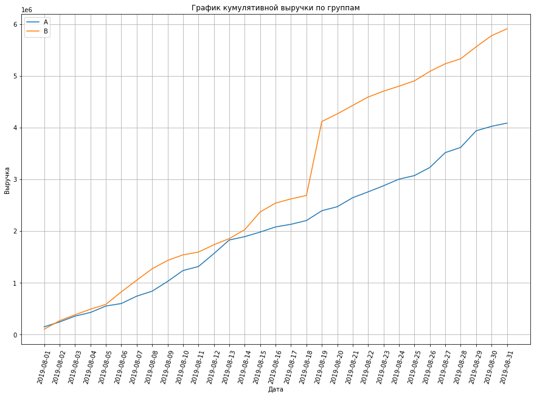

```python
#переменные для хранения кумулятивной выручки по группам
cumulative_rev_a = cumulative_data[cumulative_data['group'] == 'A'][['date','cumulative_orders','cumulative_revenue']]
cumulative_rev_b = cumulative_data[cumulative_data['group'] == 'B'][['date','cumulative_orders','cumulative_revenue']]

#графики кумулятивной выручки
plt.figure(figsize = (15,10))

plt.plot(
    cumulative_rev_a['date'],
    cumulative_rev_a['cumulative_revenue'],
    label='A'
)

plt.plot(
    cumulative_rev_b['date'],
    cumulative_rev_b['cumulative_revenue'],
    label='B'
)
plt.legend()
plt.grid(True)
plt.title('График кумулятивной выручки по группам')
plt.xlabel('Дата')
plt.ylabel('Выручка')
plt.xticks(cumulative_rev_a['date'], rotation=75)
plt.show;
```

Графики кумулятивной выручки по обеим группам стабильно растут, группа **B** показывает лучшие результаты, чем группа **A**. Однако резкий локальный рост в некоторых точках может говорить о наличии выбросов и аномалий в данных. Скорее всего, речь идёт об аномально крупных заказах либо о резком всплеске количества заказов в эти даты.

### График кумулятивного среднего чека по группам

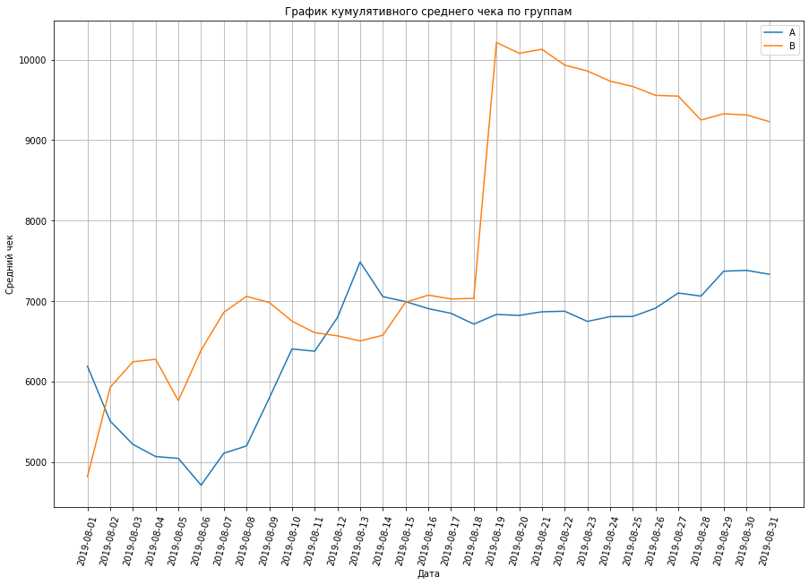

```python
plt.figure(figsize = (15,10))

plt.plot(
    cumulative_rev_a['date'],
    cumulative_rev_a['cumulative_revenue']/cumulative_rev_a['cumulative_orders'],
    label='A'
)

plt.plot(
    cumulative_rev_b['date'],
    cumulative_rev_b['cumulative_revenue']/cumulative_rev_b['cumulative_orders'],
    label='B'
)
plt.legend()
plt.grid(True)
plt.title('График кумулятивного среднего чека по группам')
plt.xlabel('Дата')
plt.ylabel('Средний чек')
plt.xticks(cumulative_rev_a['date'], rotation=75)
plt.show;
```

График кумулятивного среднего чека для группы **A** ко второй половине периода наблюдений становится равномерным. Оба графика демонстрируют резкие изменения в нескольких точках, например, график кумулятивного среднего чека для группы **B** показывет резкий скачок 19.08.2019. Вероятно, в эти даты были сделаны один или несколько несколько аномально крупных заказов, что повлияло на данные. После 19.08.2019 г. средний чек для группы **B** плавно снижается, но превышает средний чек группы **A**.

### График относительного изменения кумулятивного среднего чека группы B к группе A

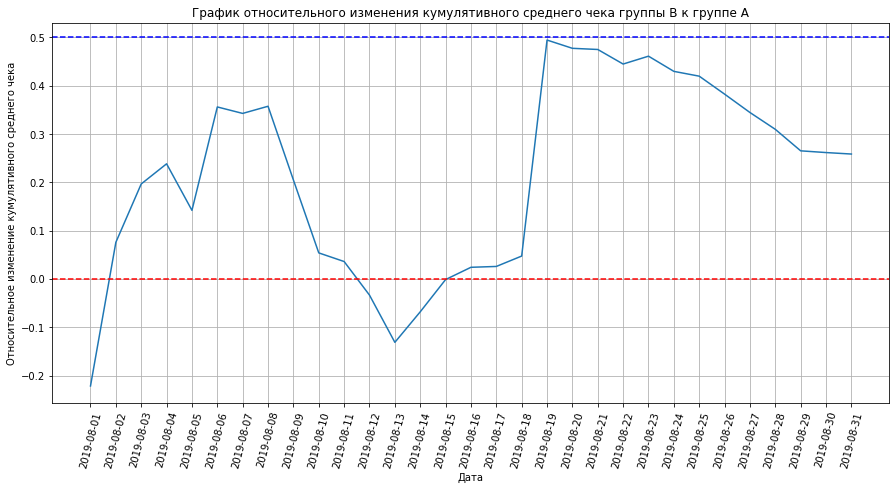

```python
#объединение датафреймов с кумулятивными выручкой и количеством заказов обеих групп
merged_cumulative_rev = cumulative_rev_a.merge(
    cumulative_rev_b,
    left_on='date',
    right_on='date',
    suffixes=['_a','_b']
)

#график относительного изменения кумулятивного среднего чека группы B к группе A
plt.figure(figsize=(15,7))

plt.plot(
    merged_cumulative_rev['date'],
    (
        merged_cumulative_rev['cumulative_revenue_b']/merged_cumulative_rev['cumulative_orders_b']
        / (merged_cumulative_rev['cumulative_revenue_a']/merged_cumulative_rev['cumulative_orders_a']) - 1
    )
)
plt.axhline(y=0, color='red', linestyle='--')
plt.axhline(y=0.5, color='blue', linestyle='--')
plt.grid(True)
plt.title('График относительного изменения кумулятивного среднего чека группы B к группе A')
plt.xlabel('Дата')
plt.ylabel('Относительное изменение кумулятивного среднего чека')
plt.xticks(cumulative_rev_a['date'], rotation=75)
plt.show;
```

Во второй половине теста средний чек группы **В** превышает средний чек группы **А**, ближе к концу теста разница постепенно уменьшается.

В нескольких точках график показывает резкие изменения, вероятно, влияние аномально больших или маленьких заказов, выбросов.

### График кумулятивного среднего количества заказов на посетителя по группам

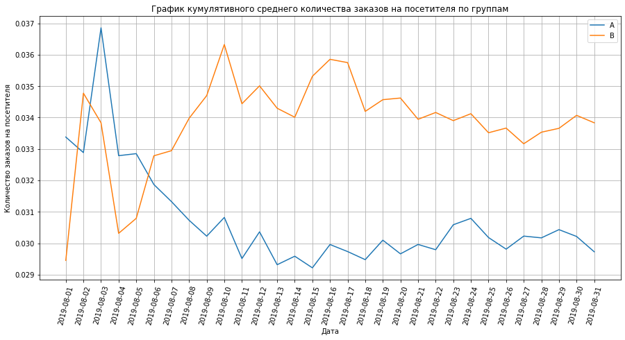

```python
#добавление столбца с количеством заказов на посетителя
cumulative_data['orders_rate'] = cumulative_data['cumulative_orders'] / cumulative_data['cumulative_visitors']

#разбиение данных по разным группам
orders_rate_a = cumulative_data[cumulative_data['group'] == 'A'][['date', 'orders_rate']]
orders_rate_b = cumulative_data[cumulative_data['group'] == 'B'][['date', 'orders_rate']]

#построение графика
plt.figure(figsize = (15,7))

plt.plot(
    orders_rate_a['date'],
    orders_rate_a['orders_rate'],
    label='A'
)

plt.plot(
    orders_rate_b['date'],
    orders_rate_b['orders_rate'],
    label='B'
)
plt.legend()
plt.grid(True)
plt.title('График кумулятивного среднего количества заказов на посетителя по группам')
plt.xlabel('Дата')
plt.ylabel('Количество заказов на посетителя')
plt.xticks(orders_rate_a['date'], rotation=75)
plt.show;
```

Среднее количество заказов на посетителя у группы **B** выше, чем у группы **A**, к концу теста показатели постепенно устанавливаются около одного значения. В нескольких точках наблюдаются резкие скачки на обоих графиках.

### График относительного изменения кумулятивного среднего количества заказов на посетителя группы B к группе A

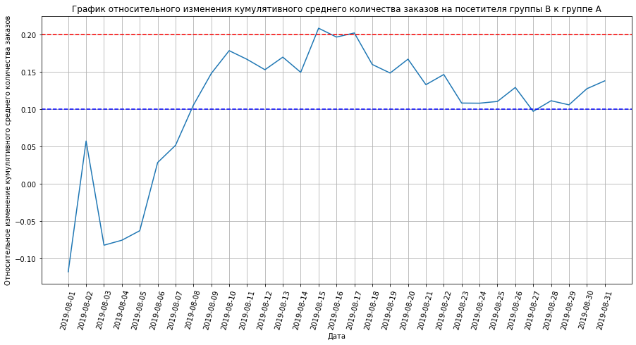

```python
#объединение данных
merged_orders_rate = orders_rate_a.merge(orders_rate_b, left_on='date', right_on='date', suffixes=['_a','_b'])

plt.figure(figsize = (15,7))

plt.plot(
    merged_orders_rate['date'],
    merged_orders_rate['orders_rate_b'] / merged_orders_rate['orders_rate_a'] - 1

)


plt.grid(True)
plt.axhline(y=0.2, color='red', linestyle='--')
plt.axhline(y=0.1, color='blue', linestyle='--')
plt.title('График относительного изменения кумулятивного среднего количества заказов на посетителя группы B к группе A')
plt.xlabel('Дата')
plt.ylabel('Относительное изменение кумулятивного среднего количества заказов')
plt.xticks(orders_rate_a['date'], rotation=75)
plt.show;
```

В начале теста группа **B** сильно уступала группе **A** по количеству заказов на посетителя, но быстро обогнала группу **A**, опередив её более чем на 20%, затем во второй половине теста разница снижалась.

### Точечный график количества заказов по пользователям

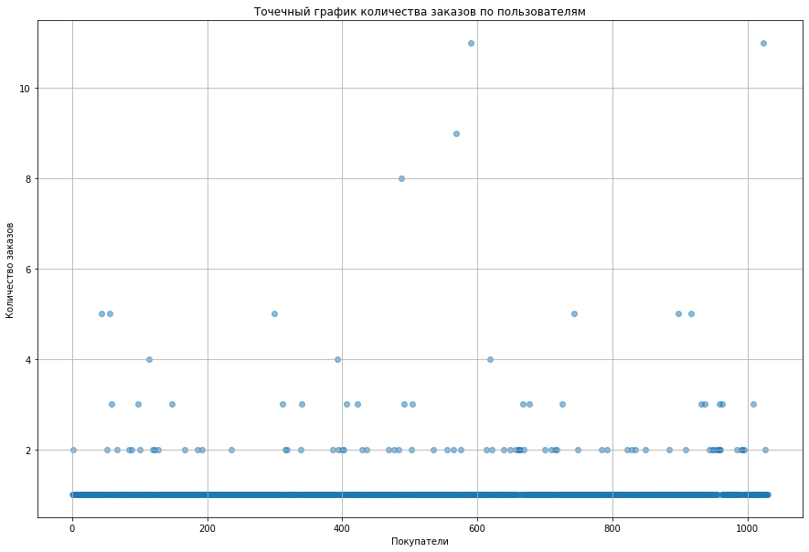

```python
orders_by_vis = orders.pivot_table(
    index='visitor_id',
    values='transaction_id',
    aggfunc='nunique'
).reset_index()

orders_by_vis.columns=['visitor_id', 'orders']

plt.figure(figsize = (15,10))

plt.scatter(orders_by_vis.index, orders_by_vis['orders'], alpha=0.5)

plt.grid(True)
plt.title('Точечный график количества заказов по пользователям')
plt.xlabel('Покупатели')
plt.ylabel('Количество заказов')

plt.show;
```

```python
orders_by_vis
```

|  | visitor_id | orders |
| --- | --- | --- |
| 0 | 5114589 | 1 |
| 1 | 6958315 | 1 |
| 2 | 8300375 | 2 |
| 3 | 11685486 | 1 |
| 4 | 39475350 | 1 |
| ... | ... | ... |
| 1026 | 4266935830 | 2 |
| 1027 | 4278982564 | 1 |
| 1028 | 4279090005 | 1 |
| 1029 | 4281247801 | 1 |
| 1030 | 4283872382 | 1 |

1031 rows × 2 columns

Пользователей, сделавших более одного заказа, крайне мало; пользователей, сделавших более 2 заказов, исчезающе мало, но есть пользователи, сделавшие больше 10 заказов.

### 95-й и 99-й перцентили количества заказов на пользователя и граница для определения аномальных пользователей

```python
#определение 95-го и 99 процентилей
orders_perc = np.percentile(orders_by_vis['orders'], [95,99])
orders_perc
```

```
array([2., 4.])
```

Поместим таких покупателей в переменную **visitors_many_orders**.

```python
visitors_many_orders = orders_by_vis.query('orders > @orders_perc[1]')['visitor_id']
```

### Точечный график стоимостей заказов

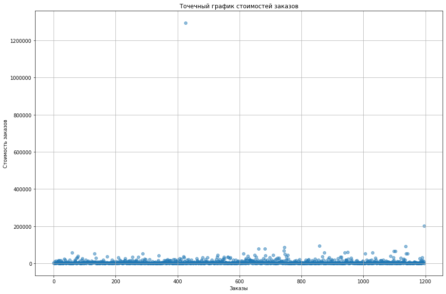

```python
plt.figure(figsize = (15,10))

plt.scatter(pd.Series(range(0, len(orders['transaction_id']))), orders['revenue'], alpha=0.5)

plt.grid(True)
plt.ticklabel_format(style='plain')
plt.title('Точечный график стоимостей заказов')
plt.xlabel('Заказы')
plt.ylabel('Стоимость заказов')


plt.show;
```

Заказ в интернет-магазине стоимостью более миллиона - это аномалия, а скорее всего ошибка. Стоимость остальных заказы находится в пределах 210000.

Построим точечный график стоимостей заказов стоимостью до 210000.

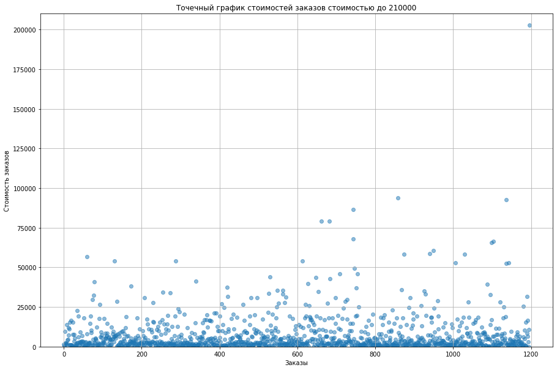

```python
plt.figure(figsize = (15,10))

plt.scatter(pd.Series(range(0, len(orders['transaction_id']))), orders['revenue'], alpha=0.5)

plt.grid(True)
plt.ticklabel_format(style='plain')
plt.title('Точечный график стоимостей заказов стоимостью до 210000')
plt.xlabel('Заказы')
plt.ylabel('Стоимость заказов')
plt.ylim(0,210000)

plt.show;
```

Заказов стоимостью более 25000 крайне мало, заказы стоимостью более 55000 - редкие исключения.

Наиболее резкие выбросы - два заказа стоимостью более 200000.

```python
#наиболее аномальные заказы
orders[orders['revenue'] > 200000]['date']
```

```
425    2019-08-19
1196   2019-08-15
Name: date, dtype: datetime64[ns]
```

Теперь понятно, что резкие скачки на графиках кумулятивных метрик вызваны аномально большими заказами.

### 95-й и 99-й перцентили стоимости заказов и граница для определения аномальных по стоимости заказов

```python
rev_perc = np.percentile(orders['revenue'], [95,99])
rev_perc
```

```
array([28000. , 58233.2])
```

99% заказов ограничены стоимостью 58233,2, этот показатель можно принять за границу и считать заказы с большей стоимостью аномалией.

Поместим таких покупателей в переменную **visitors_exp_orders** и объединим покупателей с аномально большим количеством заказов и аномально дорогими заказами в одну переменную.

```python
#покупатели с аномально дорогими заказами
visitors_exp_orders = orders.query('revenue > @rev_perc[1]')['visitor_id']

#объединение списков покупателей с аномалиями
visitors_abnormal = pd.concat(
    [visitors_many_orders, visitors_exp_orders]
).drop_duplicates().sort_values()
```

### Вывод по разделу исследовательского анализа данных A/B-теста

Графики кумулятивной выручки по обеим группам стабильно растут, группа **B** показывает лучшие результаты, чем группа **A**. Однако резкий локальный рост в некоторых точках может говорить о наличии выбросов и аномалий в данных. Скорее всего, речь идёт об аномально крупных заказах либо о резком всплеске количества заказов в эти даты.

График кумулятивного среднего чека для группы **A** ко второй половине периода наблюдений становится равномерным. Оба графика демонстрируют резкие изменения в нескольких точках, например, график кумулятивного среднего чека для группы **B** показывет резкий скачок 19.08.2019. Вероятно, в эти даты были сделаны один или несколько несколько аномально крупных заказов, что повлияло на данные. После 19.08.2019 г. средний чек для группы **B** плавно снижается, но превышает средний чек группы **A**.

Во второй половине теста средний чек группы **В** превышает средний чек группы **А**, ближе к концу теста разница постепенно уменьшается.

Среднее количество заказов на посетителя у группы B выше, чем у группы A, к концу теста показатели постепенно устанавливаются около одного значения.

В начале теста группа **B** сильно уступала группе **A** по количеству заказов на посетителя, но быстро обогнала группу **A**, опередив её более чем на 20%, затем во второй половине теста разница снижалась.

На графиках всех изученных кумулятивных метрик присутствуют резкие изменения и скачки - вероятно, влияние аномально больших или маленьких заказов, выбросов.

В целом кумулятивные метрики к концу теста стабилизировались, что означает, что собранных данных достаточно для проведения анализа.

Пользователей, сделавших более одного заказа, крайне мало; пользователей, сделавших более 2 заказов, исчезающе мало, но есть пользователи, сделавшие больше 10 заказов.

99% пользователей сделали не более 4 заказов, этот показатель можно принять за границу и считать пользователей, сделавших более 4 заказов, аномалией.

99% заказов ограничены стоимостью 58233,2, этот показатель можно принять за границу и считать заказы с большей стоимостью аномалией.

## Статистический анализ результатов A/B-теста

### Проверка гипотез

#### Cтатистическая значимость различий в среднем количестве заказов на посетителя между группами по «сырым» данным

Формулирование гипотез.

Нулевая гипотеза: среднее количество заказов на посетителя у обеих групп одинаково. Алтернативная гипотеза: среднее количество заказов на посетителя у групп **A** и **B** различается.

Для расчёта статистической значимости используем тест Уилкоксона-Манна-Уитни, так как этот тест не учитывает конкретные значения рассматриваемой величины, а значит, нечувствителен к выбросам в данных.

```python
#выборка для группы A
orders_by_vis_a = (
    orders[orders['group'] == 'A']
    .groupby('visitor_id', as_index=False)['transaction_id']
    .agg({'transaction_id':'nunique'})
)

orders_by_vis_a.columns = ['visitor_id', 'orders']

sample_a = pd.concat(
    [orders_by_vis_a['orders'],
    pd.Series(
        0,
        index=np.arange(
            0,
            visitors[visitors['group'] == 'A']['visitors'].sum() -  len(orders_by_vis_a['orders'])
        ),
        name='orders'
    )]
)

#выборка для группы B
orders_by_vis_b = (
    orders[orders['group'] == 'B']
    .groupby('visitor_id', as_index=False)['transaction_id']
    .agg({'transaction_id':'nunique'})
)

orders_by_vis_b.columns = ['visitor_id', 'orders']

sample_b = pd.concat(
    [orders_by_vis_b['orders'],
    pd.Series(
        0,
        index=np.arange(
            0,
            visitors[visitors['group'] == 'B']['visitors'].sum() - len(orders_by_vis_b['orders'])
        ),
        name='orders'
    )]
)

#уровень статистической значимости
alpha = 0.05

#p-value
result = st.mannwhitneyu(sample_a, sample_b)

display(f'p-value: {result[1]:.6f}')
if result[1] < alpha:
    display(
        'Отвергаем нулевую гипотезу: есть статистически \
значимая разница между группами в среднем количестве заказов на посетителя'
    )
else:
    display('Не получилось отвергнуть нулевую гипотезу: вывод о различии сделать нельзя')

#относительный прирост группы B к группе A
display(
    'Относительное различие между средним количеством заказов на посетителя между группами:',
    sample_b.mean()/sample_a.mean() - 1
)
```

```
'p-value: 0.016792'
```

```
'Отвергаем нулевую гипотезу: есть статистически значимая разница между группами в среднем количестве заказов на посетителя'
```

```
'Относительное различие между средним количеством заказов на посетителя между группами:'
```

```
0.13807884655320146
```

По неочищенным данным среднее количество заказов на посетителя в группе **B** статистически значимо отличается от среднего количества заказов на посетителя в группе **A**.

Выборки, полученные в результате теста, показывают, что среднее количество заказов на посетителя в группе **B** превышает этот показатель у группы **A** на 13.8%.

#### Статистическая значимость различий в среднем чеке заказа между группами по «сырым» данным

Формулирование гипотез.

Нулевая гипотеза: средний чек заказа у обеих групп одинаков. Алтернативная гипотеза: средний чек заказа у групп **A** и **B** различается.

Расчёт статистической значимости тестом Уилкоксона-Манна-Уитни.

```python
#уровень статистической значимости
alpha = 0.05

#p-value
result = st.mannwhitneyu(orders[orders['group'] == 'A']['revenue'], orders[orders['group'] == 'B']['revenue'])

display(f'p-value: {result[1]:.6f}')
if result[1] < alpha:
    display(
        'Отвергаем нулевую гипотезу: есть статистически \
значимая разница между группами в среднем количестве заказов на посетителя'
    )
else:
    display('Не получилось отвергнуть нулевую гипотезу: вывод о различии сделать нельзя')

#относительный прирост группы B к группе A
display(
    'Относительное различие между средним количеством заказов на посетителя между группами:',
    orders[orders['group'] == 'A']['revenue'].mean()/orders[orders['group'] == 'B']['revenue'].mean() - 1
)
```

```
'p-value: 0.729291'
```

```
'Не получилось отвергнуть нулевую гипотезу: вывод о различии сделать нельзя'
```

```
'Относительное различие между средним количеством заказов на посетителя между группами:'
```

```
-0.2055381427060885
```

#### Cтатистическая значимость различий в среднем количестве заказов на посетителя между группами по «очищенным» данным

Формулирование гипотез.

Нулевая гипотеза: среднее количество заказов на посетителя у обеих групп одинаково. Алтернативная гипотеза: среднее количество заказов на посетителя у групп **A** и **B** различается.

Расчёт статистической значимости тестом Уилкоксона-Манна-Уитни.

```python
#выборка для группы A
sample_a = pd.concat(
    [orders_by_vis_a.query('visitor_id not in @visitors_abnormal')['orders'],
    pd.Series(
        0,
        index=np.arange(
            0,
            visitors[visitors['group'] == 'A']['visitors'].sum() -  len(orders_by_vis_a['orders'])
        ),
        name='orders'
    )]
)

#выборка для группы B
sample_b = pd.concat(
    [orders_by_vis_b.query('visitor_id not in @visitors_abnormal')['orders'],
    pd.Series(
        0,
        index=np.arange(
            0,
            visitors[visitors['group'] == 'B']['visitors'].sum() - len(orders_by_vis_b['orders'])
        ),
        name='orders'
    )]
)

#уровень статистической значимости
alpha = 0.05

#p-value
result = st.mannwhitneyu(sample_a, sample_b)

display(f'p-value: {result[1]:.6f}')
if result[1] < alpha:
    display(
        'Отвергаем нулевую гипотезу: есть статистически \
значимая разница между группами в среднем количестве заказов на посетителя'
    )
else:
    display('Не получилось отвергнуть нулевую гипотезу: вывод о различии сделать нельзя')

#относительный прирост группы B к группе A
display(
    'Относительное различие между средним количеством заказов на посетителя между группами:',
    sample_b.mean()/sample_a.mean() - 1
)
```

```
'p-value: 0.013799'
```

```
'Отвергаем нулевую гипотезу: есть статистически значимая разница между группами в среднем количестве заказов на посетителя'
```

```
'Относительное различие между средним количеством заказов на посетителя между группами:'
```

```
0.1538912004931423
```

По очищенным данным среднее количество заказов на посетителя в группе **B** статистически значимо отличается от среднего количества заказов на посетителя в группе **A**.

#### Статистическая значимость различий в среднем чеке заказа между группами по «очищенным» данным

Формулирование гипотез.

Нулевая гипотеза: средний чек заказа у обеих групп одинаков. Алтернативная гипотеза: средний чек заказа у групп **A** и **B** различается.

Расчёт статистической значимости тестом Уилкоксона-Манна-Уитни.

```python
#уровень статистической значимости
alpha = 0.05

#p-value
result = st.mannwhitneyu(
    orders.query('group == "A" & visitor_id not in @visitors_abnormal')['revenue'],
    orders.query('group == "B" & visitor_id not in @visitors_abnormal')['revenue']
)

display(f'p-value: {result[1]:.6f}')
if result[1] < alpha:
    display(
        'Отвергаем нулевую гипотезу: есть статистически \
значимая разница между группами в среднем количестве заказов на посетителя'
    )
else:
    display('Не получилось отвергнуть нулевую гипотезу: вывод о различии сделать нельзя')

#относительный прирост группы B к группе A
display(
    'Относительное различие между средним количеством заказов на посетителя между группами:',
    (orders.query('group == "B" & visitor_id not in @visitors_abnormal')['revenue'].mean() /
     orders.query('group == "A" & visitor_id not in @visitors_abnormal')['revenue'].mean() - 1)
)
```

```
'p-value: 0.957526'
```

```
'Не получилось отвергнуть нулевую гипотезу: вывод о различии сделать нельзя'
```

```
'Относительное различие между средним количеством заказов на посетителя между группами:'
```

```
-0.01416674043653432
```

По "очищенным данным" статистически значимой разницы в среднем чеке заказа между группами **A** и **B** нет, в полученной по результатам теста выборке с "очищенными" данными средний чек группы **B** на всего на 1,42% меньше, чем в группе **A**.

## Общий вывод

### Цели и задачи проекта

**Цель проекта**: найти возможности для увеличения выручки крупного интернет-магазина.

**Задачи проекта**:

- приоритизировать гипотезы;
- проверить корректность проведения и результатов A/B-теста;
- провести статистический анализ результатов A/B-теста.

### Приоритизация гипотез

Наиболее перспективная гипотеза по RICE: добавить форму подписки на все основные страницы, чтобы собрать базу клиентов для email-рассылок (№7).

Наиболее перспективные гипотезы по ICE:

- запустить акцию, дающую скидку на товар в день рождения (№8);
- добавить два новых канала привлечения трафика, что позволит привлекать на 30% больше пользователей (№0);
- добавить форму подписки на все основные страницы, чтобы собрать базу клиентов для email-рассылок (№7).

Наименее перспективные гипотезы по ICE и RICE:

- изменить структуру категорий, что увеличит конверсию, т.к. пользователи быстрее найдут нужный товар (№3);
- запустить собственную службу доставки, что сократит срок доставки заказов (№1);
- добавить страницу отзывов клиентов о магазине, что позволит увеличить количество заказов (№5);
- изменить цвет фона главной страницы, чтобы увеличить вовлеченность пользователей (№4).

### Исследовательский анализ данных A/B-теста

В целом кумулятивные метрики к концу теста стабилизировались, что означает, что собранных данных достаточно для проведения анализа.

Графики кумулятивной выручки по обеим группам стабильно растут, группа **B** показывает лучшие результаты, чем группа **A**. Однако резкий локальный рост в некоторых точках может говорить о наличии выбросов и аномалий в данных.

График кумулятивного среднего чека для группы **A** ко второй половине периода наблюдений становится равномерным. Оба графика демонстрируют резкие изменения в нескольких точках, например, график кумулятивного среднего чека для группы **B** показывет резкий скачок 19.08.2019. Вероятно, в эти даты были сделаны один или несколько несколько аномально крупных заказов, что повлияло на данные. После 19.08.2019 г. средний чек для группы **B** плавно снижается, но превышает средний чек группы **A**.

Во второй половине теста средний чек группы **В** превышает средний чек группы **А**, ближе к концу теста разница постепенно уменьшается.

Среднее количество заказов на посетителя у группы B выше, чем у группы A, к концу теста показатели постепенно устанавливаются около одного значения.

В начале теста группа **B** сильно уступала группе **A** по количеству заказов на посетителя, но быстро обогнала группу **A**, опередив её более чем на 20%, затем во второй половине теста разница снижалась.

На графиках всех изученных кумулятивных метрик присутствуют резкие изменения и скачки - вероятно, влияние аномально больших или маленьких заказов, выбросов.

### Решение по результатам теста

В целом кумулятивные метрики к концу теста стабилизировались, что означает, что собранных данных достаточно для проведения анализа.

Графики кумулятивных метрик группы **B** демонстрируют лучшие показатели выручки и количества заказов на посетителя, чем группы **A**. Графики выручки и кумулятивного среднего чека группы **B** показывают лучншие результаты, чем группы **A**, одднако это, видимо, влияние аномально больших заказов.

И по "сырым", и по очищенным от аномалий данным группа **B** показывает статистически значимое относительное увеличение среднего количества заказов на посетителя, статистически значимого различия в среднем чеке заказа нет.

### О качестве данных

Дубликатов и явных ошибок в датасетах нет. Данные о количестве и размере заказов содержат аномалии и выбросы, возможно, ошибочные значения.

58 покупателей (5,3% от общего количества) попали в обе группы, что говорит о проблеме в системе разбиения трафика при проведении A/B-теста; данные о заказах таких пользователей содержатся в 181 строке (15,1%) датафрейма **orders**, что приводит к искажению данных. Поэтому к результатам теста и их анализу нужно отнестись с осторожностью.